# Hutterite iPSC Panel Pluritest

Courtney Kagan

Last updated: 2015-04-23

This is the workflow used for pluritest on the 73 Hutterite iPSC samples and 11 samples with cardiomyocytes treated with doxorubicin.

## Pluritest

Set working directory on spudhead

```bash
cd /mnt/gluster/internal_supp/hutt_ipsc
```

# PluriScore

All samples including 11 samples from a doxorubicin treatment and the 73 Hutterite iPSCs are assigned a pluripotency score and novelty score based on gemone-wide expression. In this first plot all of the samples above the red dashed line (at 20) are considered pluripotent. All samples below the blue dashed line are not pluripotent. All iPSCs have been classified as pluripotent.

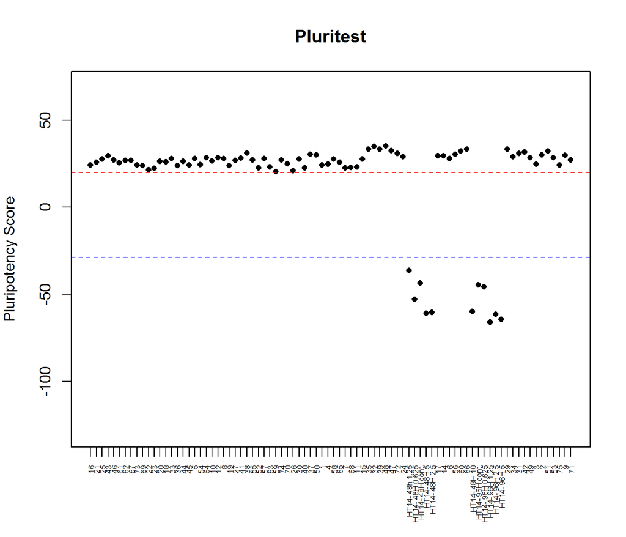